# Apiary_LRR_Analysis

David Showalter

8/2/2021

## Study description

In each of 5 reps 25 1/20 acre circular plots were planted with 34 1-0 (1 year old) Douglas fir seedlings. 5 plots per rep were each assigned to a treatment: DF0Y, RA10Y, CW10Y, RA20Y, CW20Y. (plots = 125, tmt = 5, rep = 5, plots/tmt/rep = 5). 34 seedlings/plot = approx 4,250 trees.

## Loading libraries

```r
library(readxl)
library(readr)
library(tidyverse)
```

```r
library(ggplot2)
```

## Importing data

Two multi-sheet workboooks were provided by Anna Leon of Weyerhauser (Anna.Leon@weyerhaeuser.com). One with keys for metadata codes and one with coded data plus a dictionary for column names

Also recieve raw datasheets which were transcribed into Excell and imported.

Jan 2022 received additional digital data from John Browning. Contains 1995 and 2011 measurements for plots A B and C. As well as stem maps for A and B. This should fill in the data for the plots A11-A15 and A31-A35 that were missing raw datasheets and add a 1995 measurement for C plots (DF0Y). The fields for this data are somewhat different and include a field called “dead year”. Sheet 1 Data range B2:K2214

NOTE: Lab computer path “showalt_d/”, home computer “showa/”

```r
#reading in abbreviation code sheets from metadata workbook from Anna
Apiary_TMTs <- read_excel("C:/Users/showa/Documents/GitHub/Apiary_LRR/raw_data/Apiary_2020_Path_Data_All_for_Jared_2.xlsx", sheet = "Treatments", range = "A1:C6", col_names = TRUE)
colnames(Apiary_TMTs)<-c("TMT_code","TMT_short","TMT_name")

Species_codes <- read_excel("C:/Users/showa/Documents/GitHub/Apiary_LRR/raw_data/Apiary_Measurement_Codes.xls",sheet = "Species_Codes", range = "A5:B130", col_names = FALSE)
colnames(Species_codes)<-c("Species_Code","Species_name")

Origin_codes <- read_excel("C:/Users/showa/Documents/GitHub/Apiary_LRR/raw_data/Apiary_Measurement_Codes.xls",sheet = "Origin_Codes", range = "A5:B10", col_names = FALSE)
colnames(Origin_codes)<-c("Origin_Code","Origin")

Status_codes <- read_excel("C:/Users/showa/Documents/GitHub/Apiary_LRR/raw_data/Apiary_Measurement_Codes.xls",sheet = "Status_Codes", range = "A5:B19", col_names = FALSE)
colnames(Status_codes)<-c("Status_Code","Status")

Damage_codes <- read_excel("C:/Users/showa/Documents/GitHub/Apiary_LRR/raw_data/Apiary_Measurement_Codes.xls",sheet = "Damage_Codes", range = "A5:B62", col_names = FALSE)
colnames(Damage_codes)<-c("Damage_Code","Damage")

Position_codes <- read_excel("C:/Users/showa/Documents/GitHub/Apiary_LRR/raw_data/Apiary_Measurement_Codes.xls",sheet = "Position_Codes", range = "A7:B14", col_names = FALSE)
colnames(Position_codes)<-c("Position_Code","Position")

Damage_amount_codes <- read_excel("C:/Users/showa/Documents/GitHub/Apiary_LRR/raw_data/Apiary_Measurement_Codes.xls",sheet = "Amount_Codes", range = "A5:B54", col_names = FALSE)
colnames(Damage_amount_codes)<-c("Damage_Amount_Code","Damage_Amount")

#reading in dictionary sheet from data workbook
Data_dict <- read_excel("C:/Users/showa/Documents/GitHub/Apiary_LRR/raw_data/Apiary_2020_Path_Data_All_for_Jared_2.xlsx",sheet = "Data_Dictionary", range = "A3:B23", col_names = FALSE)
colnames(Data_dict)<-c("Column_Name","Description")

#reading in data Note that "data_input_edits.xlsx" has been manually reviewed and corrected based on inspection of data in R.
A_plots <- read_excel("C:/Users/showa/Documents/GitHub/Apiary_LRR/raw_data/data_input_edits.xlsx",sheet = "A-Plots", col_names = TRUE)
#unique(A_plots$AMT1)
A_plots$AMT1[A_plots$AMT1==0]<-NA

B_plots <- read_excel("C:/Users/showa/Documents/GitHub/Apiary_LRR/raw_data/data_input_edits.xlsx",sheet = "B-Plots", col_names = TRUE)

C_plots <- read_excel("C:/Users/showa/Documents/GitHub/Apiary_LRR/raw_data/data_input_edits.xlsx",sheet = "C-Plots", col_names = TRUE)
#checking nonconforming trt entries with "y" instead of "Y"
#unique(C_plots$TRT)
C_plots$TRT[C_plots$TRT=="DF0y"]<-"DF0Y"

D_plots <- read_excel("C:/Users/showa/Documents/GitHub/Apiary_LRR/raw_data/data_input_edits.xlsx",sheet = "D-Plots", col_names = TRUE)
#checking nonconforming trt entries with "y" instead of "Y"
#unique(D_plots$TRT)
#unique(D_plots$DAM1)
#unique(D_plots$AMT1)
D_plots$TRT[D_plots$TRT=="RA20y"]<-"RA20Y"
#D_plots$DAM1[D_plots$DAM1=="Blank"]<-NA
#D_plots$AMT1[D_plots$AMT1=="Blank"]<-NA

E_plots <- read_excel("C:/Users/showa/Documents/GitHub/Apiary_LRR/raw_data/data_input_edits.xlsx",sheet = "E-Plots", col_names = TRUE)

#combine all treatments together into one dataset and change coded variables to factors rather than numbers
combined_data<-rbind(A_plots,B_plots,C_plots,D_plots,E_plots)


#unique(combined_data$TRT)
combined_data$LOC<-as.factor(combined_data$LOC)
combined_data$PLOT<-as.factor(combined_data$PLOT)
combined_data$SUBPLOT<-as.factor(combined_data$SUBPLOT)
combined_data$REP<-as.factor(combined_data$REP)
combined_data$TRT<-as.factor(combined_data$TRT)
combined_data$TREE<-as.character(combined_data$TREE)
combined_data$SP<-as.character(combined_data$SP)
combined_data$OR<-as.character(combined_data$OR)
combined_data$OSTS<-as.character(combined_data$OSTS)
combined_data$NSTS<-as.character(combined_data$NSTS)
combined_data$DAM1<-as.character(combined_data$DAM1)
combined_data$POS1<-as.character(combined_data$POS1)
combined_data$AMT1<-as.character(combined_data$AMT1)

#removing false zeros for DBH measurements
combined_data$NDBH[combined_data$NDBH==0]<-NA
combined_data$ODBH[combined_data$ODBH==0]<-NA

#add treatment code variable and unique Tree and subplot ID variables
combined_data$TRT_code<-ifelse(combined_data$TRT=="RA10Y", "A", ifelse(combined_data$TRT=="CW10Y","B", ifelse(combined_data$TRT=="DF0Y","C", ifelse(combined_data$TRT=="RA20Y","D","E"))))
combined_data$TRT_code<-as.factor(combined_data$TRT_code)
combined_data$SUBPLOT_ID<-as.factor(paste(combined_data$TRT_code,combined_data$REP,combined_data$SUBPLOT, sep = ""))
combined_data$Tree_ID<-paste(combined_data$SUBPLOT_ID,combined_data$TREE, sep = "_")

#Repeat similar process for transcribed datasheets adding new dates.

A_plots_2<- read_excel("C:/Users/showa/Documents/GitHub/Apiary_LRR/raw_data/Stem_maps_and_datasheets/transcribed_datasheets_87_95_11_common_format.xlsx",sheet = "A_Plots", col_names = TRUE)
B_plots_2<- read_excel("C:/Users/showa/Documents/GitHub/Apiary_LRR/raw_data/Stem_maps_and_datasheets/transcribed_datasheets_87_95_11_common_format.xlsx",sheet = "B_Plots", col_names = TRUE)
C_plots_2<- read_excel("C:/Users/showa/Documents/GitHub/Apiary_LRR/raw_data/Stem_maps_and_datasheets/transcribed_datasheets_87_95_11_common_format.xlsx",sheet = "C_Plots", col_names = TRUE)

new_combined_data<-rbind(A_plots_2,B_plots_2,C_plots_2)

new_combined_data$LOC<-as.factor(new_combined_data$LOC)
new_combined_data$PLOT<-as.factor(new_combined_data$PLOT)
new_combined_data$SUBPLOT<-as.factor(new_combined_data$SUBPLOT)
new_combined_data$REP<-as.factor(new_combined_data$REP)
new_combined_data$TRT<-as.factor(new_combined_data$TRT)
new_combined_data$TREE<-as.character(new_combined_data$TREE)
new_combined_data$DAM1<-as.character(new_combined_data$DAM1)
new_combined_data$LASTTREE<-as.character(new_combined_data$LASTTREE)
new_combined_data$DIA_87_mm<-as.numeric(new_combined_data$DIA_87_mm)
new_combined_data$DIA_95_mm<-as.numeric(new_combined_data$DIA_95_mm)
new_combined_data$DIA_11_mm<-as.numeric(new_combined_data$DIA_11_mm)

new_combined_data$TRT_code<-ifelse(new_combined_data$TRT=="RA10Y", "A", ifelse(new_combined_data$TRT=="CW10Y","B", "C"))
new_combined_data$TRT_code<-as.factor(new_combined_data$TRT_code)
new_combined_data$SUBPLOT_ID<-as.factor(paste(new_combined_data$TRT_code,new_combined_data$REP,new_combined_data$SUBPLOT, sep = ""))
new_combined_data$Tree_ID<-paste(new_combined_data$SUBPLOT_ID,new_combined_data$TREE, sep = "_")


#adding January data to add 1995 data for C plots (DF0)

#it may be easiest to manually add this data to the input file above (new_combined_data) #C:/Users/showa/Documents/GitHub/Apiary_LRR/raw_data/Stem_maps_and_datasheets/transcribed_datasheets_87_95_11_common_format.xlsx > #C:/Users/showa/Documents/GitHub/Apiary_LRR/raw_data/Stem_maps_and_datasheets/transcribed_datasheets_87_95_11_common_format_2022_update.xlsx

#saveRDS(combined_data, file="C:/Users/showa/Documents/GitHub/Apiary_LRR/raw_data/combined_trt_data.Rds")

#saveRDS(new_combined_data, file="C:/Users/showa/Documents/GitHub/Apiary_LRR/raw_data/Stem_maps_and_datasheets/new_combined_trt_data.Rds")

#write.csv(combined_data, file="C:/Users/showa/Documents/GitHub/Apiary_LRR/raw_data/combined_trt_data.csv", row.names = FALSE)

#write.csv(new_combined_data, file="C:/Users/showa/Documents/GitHub/Apiary_LRR/raw_data/Stem_maps_and_datasheets/new_combined_trt_data.csv", row.names = FALSE)
```

## Combining new and old datasets

```r
#attempting to combine new_combined_data (transcribed) and combined_data (excell sheet from Anna)

small_keep<-c("DIA_87_mm","DIA_95_mm","DIA_11_mm","STS_87","STS_95","STS_11","DAM1","DEAD_YEAR","Tree_ID")
new_combined_data_small<-as.data.frame(new_combined_data[,(colnames(new_combined_data) %in% small_keep)])

#combined_data$DEAD_YEAR<-as.double(NA)
#combined_data$DIA_87_mm<-as.double(NA)
#combined_data$HT_87<-as.double(NA)
#combined_data$DIA_95_mm<-as.double(NA)
#combined_data$HT_95<-as.character(NA)
#combined_data$DIA_11_mm<-as.double(NA)
#combined_data$HT_11<-as.character(NA)
#combined_data$STS_87<-as.double(NA)
#combined_data$STS_95<-as.double(NA)
#combined_data$STS_11<-as.double(NA)



test<-merge.data.frame(new_combined_data_small, combined_data, by= "Tree_ID", all.y = TRUE)
# checking for instances when DIA_11_mm and ODBH (supposedly 2011) are more than 15 mm different
# making a flag. Counding the flags. Subsetting the data for flags.
test$DBH_diff<-(test$ODBH - test$DIA_11_mm)
test$dbh_flag<- ifelse(abs(test$DBH_diff) >15,TRUE,FALSE)
flag_count<-sum(test$dbh_flag, na.rm=TRUE)
flag_count
```

```
## [1] 0
```

```r
DBH_flags<-as.data.frame(test[which(test$dbh_flag==TRUE),c("Tree_ID","DIA_87_mm","DIA_95_mm","STS_11","OSTS","DIA_11_mm","ODBH","NDBH","DBH_diff","dbh_flag")])

# renaming
full_data<- as.data.frame(test)

# checking when STS_11 and OSTS don't match, as with diameter above.

full_data$STS_flag <- ifelse(full_data$STS_11!=full_data$OSTS, TRUE, FALSE)
STS_flags<-as.data.frame(full_data[which(full_data$STS_flag==TRUE),c("Tree_ID","STS_87","STS_95","STS_11","OSTS","NSTS","DIA_87_mm","DIA_95_mm","DIA_11_mm","ODBH","NDBH")])
STS_flag_count<-sum(full_data$STS_flag, na.rm=TRUE)
STS_flag_count
```

```
## [1] 391
```

```r
# subsetting to when STS_11=1 and separately when NSTS=1
STS_flags_1<-as.data.frame(STS_flags[which(STS_flags$STS_11==1),])
STS_flags_2<-as.data.frame(STS_flags[which(STS_flags$NSTS==1),])

# calculating differences in ODBH and NDBH to identify possible dead trees that didn't grow between the 2 measurements
full_data$new_dia_diff<-(full_data$NDBH - full_data$ODBH)
full_data$nd_dif_flag<- ifelse(
  (
    abs(full_data$new_dia_diff)
    < 5
     ),1,0)
nd_dif_flag_count<-sum(full_data$nd_dif_flag, na.rm=TRUE)
nd_dif_flag_count
```

```
## [1] 1530
```

```r
# subsetting this data to trees which have OSTS or NSTS =1 contradicting their living status
DIA_diff_sts<-as.data.frame(full_data[which((full_data$nd_dif_flag==1) & (full_data$NSTS=="1")),c("Tree_ID","STS_87","STS_95","STS_11","OSTS","NSTS","DIA_87_mm","DIA_95_mm","DIA_11_mm","ODBH","NDBH")])

# checking for trees with ODBH greater than 5 mm larger than NDBH   #there are none
#oops<-full_data[which(full_data$ODBH > (full_data$NDBH + 5)),"Tree_ID"]

#Using ODBH values for missing DIA_11_mm values

full_data$DBH_11<-ifelse(is.na(full_data$DIA_11_mm),full_data$ODBH,full_data$DIA_11_mm)

#and for status values

full_data$STS_2011<-ifelse(is.na(full_data$STS_11),full_data$OSTS,full_data$STS_11)


#write.csv(full_data, file="C:/Users/showa/Documents/GitHub/Apiary_LRR/raw_data/full_data.csv", row.names = FALSE)

#saveRDS(full_data, file="C:/Users/showa/Documents/GitHub/Apiary_LRR/raw_data/full_data.Rds")
```

## Data Summarization

```r
#full_data<- readRDS("C:/Users/showa/Documents/GitHub/Apiary_LRR/raw_data/full_data.Rds")

#looking at entries which have notes
#notes<-combined_data[which(is.na(combined_data$NOTE)==FALSE),]
#glimpse(notes)
#unique(notes$NOTE)
#note_summary<-notes %>% group_by(NOTE, TRT) %>% summarise(count=n())
#note_summary
#plot_notes<-notes[which(notes$NOTE=="Tree already in Plot 5021"|notes$NOTE=="Tree on Plot 5035"|notes$NOTE=="Tree on Plot 5042"),]
#plot_notes
#subsetting the data to remove trees with notes indicating assignment to multiple plots
#combined_data2<-combined_data[-which(combined_data$NOTE=="Tree already in Plot 5021"),]


#summarizing tree count by TRT and REP
TRTxREP_summary<-full_data %>% group_by(TRT, REP, .drop=FALSE) %>% summarise(count=n())
TRTxREP_summary
```

```
## # A tibble: 25 x 3
## # Groups:   TRT [5]
##    TRT   REP   count
##    <fct> <fct> <int>
##  1 CW10Y 0       177
##  2 CW10Y 1       162
##  3 CW10Y 2       162
##  4 CW10Y 3       160
##  5 CW10Y 4       155
##  6 CW20Y 0       159
##  7 CW20Y 1       203
##  8 CW20Y 2       201
##  9 CW20Y 3       172
## 10 CW20Y 4       169
## # ... with 15 more rows
```

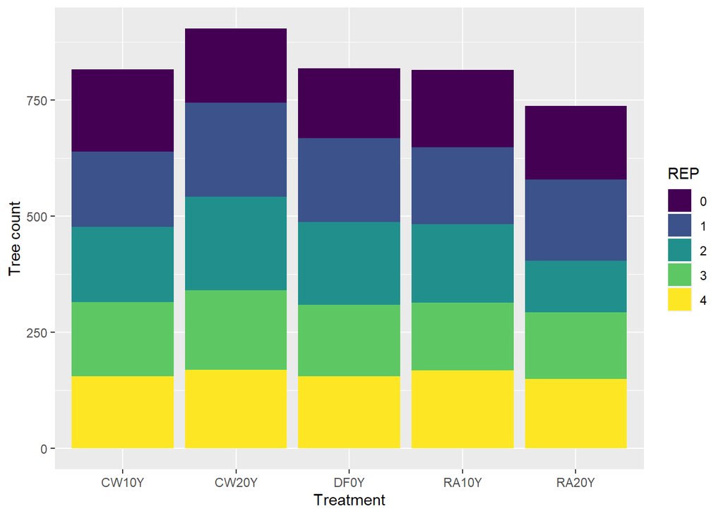

```r
ggplot(TRTxREP_summary,aes(x=TRT,y=count,fill=REP ))+geom_col()+scale_fill_viridis_d()+ylab("Tree count")+xlab("Treatment")
```

```r
#additionaly summarizing by subplot
TRTxREPxSub_summary<-combined_data %>% group_by(TRT, REP, SUBPLOT, .drop=FALSE) %>% summarise(count=n())
TRTxREPxSub_summary
```

```
## # A tibble: 125 x 4
## # Groups:   TRT, REP [25]
##    TRT   REP   SUBPLOT count
##    <fct> <fct> <fct>   <int>
##  1 CW10Y 0     1          39
##  2 CW10Y 0     2          36
##  3 CW10Y 0     3          33
##  4 CW10Y 0     4          34
##  5 CW10Y 0     5          35
##  6 CW10Y 1     1          32
##  7 CW10Y 1     2          26
##  8 CW10Y 1     3          34
##  9 CW10Y 1     4          37
## 10 CW10Y 1     5          33
## # ... with 115 more rows
```

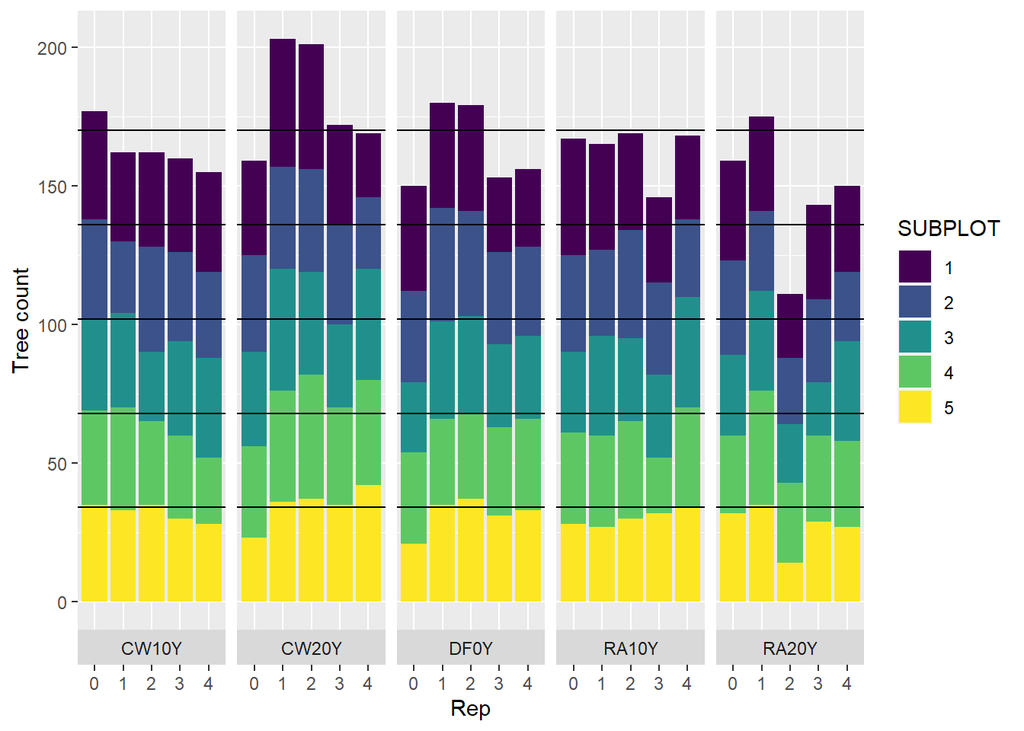

```r
ggplot(TRTxREPxSub_summary,aes(x=REP,y=count,fill=SUBPLOT )) +geom_col()+scale_fill_viridis_d()+ylab("Tree count")+xlab("Rep")+ facet_grid(~TRT, scales = "fixed", space = "free_x", switch = "x") + geom_hline(yintercept = 170)+ geom_hline(yintercept = 34) + geom_hline(yintercept = 68)+ geom_hline(yintercept = 102)+ geom_hline(yintercept = 136)
```

```r
ggsave("C:/Users/showa/Documents/GitHub/Apiary_LRR/Trees_per_subplot.pdf")

#there appears to be an imbalance of trees between treatments
#trying to look for duplicate TREE ID numbers
#dupes<-combined_data[which(duplicated(combined_data$TREE)==TRUE),]
#dupe_TRT<-dupes %>% group_by(TREE) %>% summarise(count=n())
#dupe_full<-combined_data %>% group_by(TREE) %>% summarise(count=n())
#dupe_full2<-dupe_full[which(dupe_full$count>1),]
#glimpse(dupe_full2)
#dupe_fullx<-combined_data2 %>% group_by(TREE) %>% summarise(count=n())
#dupe_fullx2<-dupe_full[which(dupe_fullx$count>1),]
#glimpse(dupe_fullx2)
#this shows that there are 797 tree numbers that appear more than once in the dataset.  Are they supposed to be unique? removing the 9 with notes as to duplication reduced the total number of duplicates by 9, suggesting that there really are many duplicate measuremetns in the dataset.

#creating a list of duplicated tree numbers and subsetting the dataset to look at only those to see patterns
#dupe_trees<-as.tibble(dupe_full2[,1])
#tree_dup_data<-combined_data[which(combined_data$TREE %in% dupe_trees$TREE),]
#sorting by TREE ID
#ordered_tree_dup_data<-tree_dup_data[order(tree_dup_data$TREE),]
#saveRDS(ordered_tree_dup_data, file="C:/Users/showa/Documents/GitHub/Apiary_LRR/raw_data/duplicated_trees.Rds")

#write.csv(ordered_tree_dup_data, file="C:/Users/showa/Documents/GitHub/Apiary_LRR/raw_data/duplicated_trees.csv", row.names = FALSE)

#adding "duplicated" flag for tree IDs that are duplicated in the dataset

#combined_data2$dup<-if_else(duplicated(combined_data2$TREE)==TRUE, "1","0")
#TRTxREPxdup_summary<-combined_data2 %>% group_by(TRT, REP, dup, .drop=FALSE) %>% summarise(count=n())
#TRTxREPxdup_summary
#ggplot(TRTxREPxdup_summary,aes(x=REP,y=count,fill=dup ))+geom_col()+scale_fill_viridis_d()+ylab("Tree count")+xlab("Treatment")+ facet_grid(~TRT, scales = "fixed", space = "free_x", switch = "x")
#TRTxREPxSUBxdup_summary<-combined_data2 %>% group_by(TRT, REP, SUBPLOT, dup, .drop=FALSE) %>% summarise(count=n())
#TRTxREPxSUBxdup_summary
#ggplot(TRTxREPxSUBxdup_summary,aes(x=SUBPLOT,y=count,fill=dup ))+geom_col()+scale_fill_viridis_d()+ylab("Tree count")+xlab("Subplot")+ facet_grid(rows=vars(REP), cols=vars(TRT), scales = "fixed", space = "free_x", switch = "x") + geom_hline(yintercept=34)
#ggsave("C:/Users/showa/Documents/GitHub/Apiary_LRR/Duplicated_Trees_per_subplot.pdf")
```

```r
TRTxNSTS_summary<-combined_data %>% group_by(TRT, NSTS, .drop=FALSE) %>% summarise(count=n())
TRTxNSTS_summary
```

```
## # A tibble: 10 x 3
## # Groups:   TRT [5]
##    TRT   NSTS  count
##    <fct> <chr> <int>
##  1 CW10Y 1       373
##  2 CW10Y 3       443
##  3 CW20Y 1       663
##  4 CW20Y 3       241
##  5 DF0Y  1       278
##  6 DF0Y  3       540
##  7 RA10Y 1       387
##  8 RA10Y 3       428
##  9 RA20Y 1       605
## 10 RA20Y 3       133
```

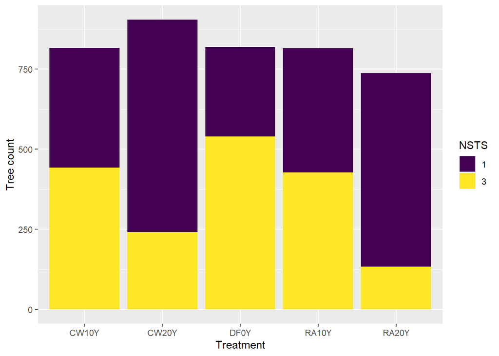

```r
ggplot(TRTxNSTS_summary,aes(x=TRT,y=count,fill=NSTS ))+geom_col()+scale_fill_viridis_d()+ylab("Tree count")+xlab("Treatment")
```

```r
TRTxOSTS_summary<-combined_data %>% group_by(TRT, OSTS, .drop=FALSE) %>% summarise(count=n())
TRTxOSTS_summary
```

```
## # A tibble: 11 x 3
## # Groups:   TRT [5]
##    TRT   OSTS  count
##    <fct> <chr> <int>
##  1 CW10Y 1       447
##  2 CW10Y 3       368
##  3 CW10Y <NA>      1
##  4 CW20Y 1       824
##  5 CW20Y 3        80
##  6 DF0Y  1       330
##  7 DF0Y  3       488
##  8 RA10Y 1       471
##  9 RA10Y 3       344
## 10 RA20Y 1       658
## 11 RA20Y 3        80
```

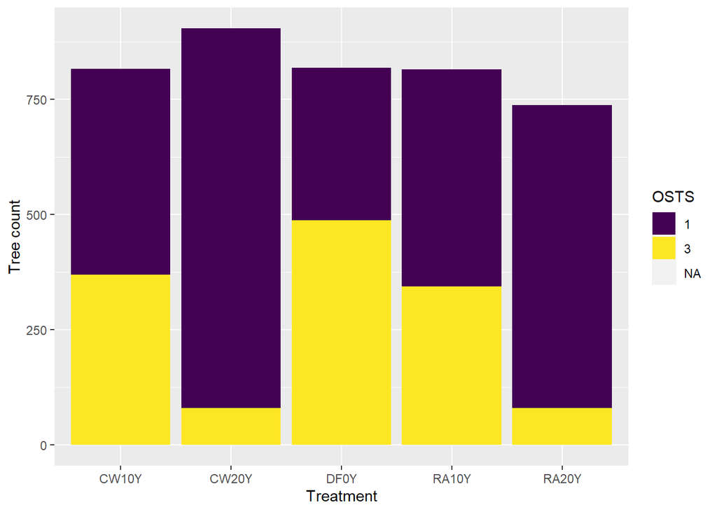

```r
#ggplot(TRTxOSTS_summary,aes(x=TRT,y=count,fill=OSTS ))+geom_col()+scale_fill_viridis_d()+ylab("Tree count")+xlab("Treatment")
ggplot(TRTxOSTS_summary,aes(x=TRT,y=count,fill=OSTS))+geom_col()+scale_fill_viridis_d()+ylab("Tree count")+xlab("Treatment")
```

```r
#TRTxDAM_summary<-combined_data %>% group_by(TRT, DAM1) %>% summarise(count=n())
#TRTxDAM_summary

DAM_summary<-combined_data %>% group_by(DAM1) %>% summarise(count=n())
DAM_summary
```

```
## # A tibble: 13 x 2
##    DAM1  count
##    <chr> <int>
##  1 100     198
##  2 400     737
##  3 499       1
##  4 500       1
##  5 605       2
##  6 608       1
##  7 700      84
##  8 800      78
##  9 806       1
## 10 807     418
## 11 808     163
## 12 Blank     1
## 13 <NA>   2406
```

```r
#write.csv(DAM_summary, file="C:/Users/showa/Documents/LeBoldus_Lab/Laminated_Root_Rot/Apiariy_LRR/raw_data/DAM_summary.csv", row.names = FALSE)

AMT_summary<-combined_data %>% group_by(AMT1) %>% summarise(count=n())
AMT_summary
```

```
## # A tibble: 19 x 2
##    AMT1  count
##    <chr> <int>
##  1 16        1
##  2 21        9
##  3 22       12
##  4 23        9
##  5 24        4
##  6 25        4
##  7 26      850
##  8 31        8
##  9 32       18
## 10 33       27
## 11 34       13
## 12 35      616
## 13 39       15
## 14 40       13
## 15 42        5
## 16 43       14
## 17 808       4
## 18 Blank     1
## 19 <NA>   2468
```

```r
DAMxAMT_summary<-combined_data %>% group_by(DAM1, AMT1) %>% summarise(count=n())
DAMxAMT_summary
```

```
## # A tibble: 65 x 3
## # Groups:   DAM1 [13]
##    DAM1  AMT1  count
##    <chr> <chr> <int>
##  1 100   21        3
##  2 100   22        4
##  3 100   23        2
##  4 100   25        1
##  5 100   26       40
##  6 100   31        2
##  7 100   32        3
##  8 100   33        2
##  9 100   35      100
## 10 100   39       15
## # ... with 55 more rows
```

```r
POS_summary<-combined_data %>% group_by(POS1) %>% summarise(count=n())
POS_summary
```

```
## # A tibble: 7 x 2
##   POS1  count
##   <chr> <int>
## 1 1        18
## 2 2        13
## 3 3        34
## 4 5         7
## 5 7      1405
## 6 8       141
## 7 <NA>   2473
```

```r
OR_summary<-combined_data %>% group_by(OR) %>% summarise(count=n())
OR_summary
```

```
## # A tibble: 2 x 2
##   OR    count
##   <chr> <int>
## 1 3      4019
## 2 <NA>     72
```

```r
#returning the entries for which AMT1 is 808, an invalid code
#AMT_808<-combined_data[which(combined_data$AMT1 == 808),]
#write.csv(AMT_808, file="C:/Users/showa/Documents/LeBoldus_Lab/Laminated_Root_Rot/Apiariy_LRR/raw_data/amt_808_data.csv", row.names = FALSE)

#fix
combined_data$AMT1[combined_data$AMT1 == 808]<-NA

#returning the entries for which NDBH is NA or 0 without explanation
DBH_NA<-combined_data[is.na(combined_data$NDBH),]
DBH_NA_no_explain<-DBH_NA[is.na(DBH_NA$AMT1),]
#write.csv(DBH_NA_no_explain, file="C:/Users/showa/Documents/LeBoldus_Lab/Laminated_Root_Rot/Apiariy_LRR/raw_data/DBH_NA_no_explain_data.csv", row.names = FALSE)

#returning the entries for which SP is NA
#SP_0<-combined_data[is.na(combined_data$SP),]
#fix
combined_data$SP<-"DF"
#write.csv(SP_0, file="C:/Users/showa/Documents/LeBoldus_Lab/Laminated_Root_Rot/Apiariy_LRR/raw_data/SP_0_data.csv", row.names = FALSE)
```

## Remaining questions

Note says that DF tretament “C” was 45 years old in 2020.Thus, plots were established in 1975. All treatments were started at the same time follwing clearcut. DF in 10 year roation treatments are 35 (45-10) years old and in 20 year treatments 25 (45-20) years old.

Mike indicated that there were 34 trees planted in each of the cicular observation subplots.

To what year(s) do(es) the “old” measurements in the provided data refer? mean DBH of 20y rotations for “ODBH” old dbh is 7-9cm, so maybe 2010 when the doug firs would have been ~15 yo Anna confirmed that the “old” measurements refer to 2011.

If this is the case, could we recode the measurements in terms of DF age? So assuming 2010 old DBH for DF0y would be 35Y, old DBH for 10y trts would be 25Y, for 20y trts would be 15y. New (2020) DBH for DF0y would be 45Y, old DBH for 10y trts would be 35Y, for 20y trts would be 25y. Could create this variable as “DF_age” with data in long format? This is done below.

Are there any additional useful maps? Anna? Mike? Do we have coordinates or GIS objects for plot Centers

11 trees without NDBH measurements. Are they duplicated in other plots? Remove them? No, they are dead (or one fused trunk).

Randomization/exp design. RCB? Is there a stem map and/or do the tree numbers refer to a position in the subplot?

## Converting to long data format

```r
#pivot to long data by old and new
#pivoting data from wide to long format

#checking similary of column types before combining
#glimpse(full_data)
#as.character  Tree_ID TREE LASTTREE  STS_87 STS_95  STS_11 STS_2011 OSTS  NSTS  DAM1.x(2011) DAM1.y(2020)
full_data$Tree_ID<-as.character(full_data$Tree_ID)
full_data$TREE<-as.character(full_data$TREE)
full_data$LASTTREE<-as.character(full_data$LASTTREE)
full_data$STS_87<-as.character(full_data$STS_87)
full_data$STS_95<-as.character(full_data$STS_95)
full_data$STS_11<-as.character(full_data$STS_11)
full_data$STS_2011<-as.character(full_data$STS_2011)
full_data$OSTS<-as.character(full_data$OSTS)
full_data$NSTS<-as.character(full_data$NSTS)
full_data$DAM1.x<-as.character(full_data$DAM1.x)
full_data$DAM1.y<-as.character(full_data$DAM1.y)

#as.double DIA_87_mm  DIA_97_mm DIA_11_mm DBH_11 ODBH NDBH
full_data$DIA_87_mm<-as.double(full_data$DIA_87_mm)
full_data$DIA_95_mm<-as.double(full_data$DIA_95_mm)
full_data$DIA_11_mm<-as.double(full_data$DIA_11_mm)
full_data$DBH_11<-as.double(full_data$DBH_11)
full_data$ODBH<-as.double(full_data$ODBH)
full_data$NDBH<-as.double(full_data$NDBH)

#as.factor PLOT REP SUBPLOT TRT TRT_code  SUBPLOT_ID
full_data$PLOT<-as.factor(full_data$PLOT)
full_data$REP<-as.factor(full_data$REP)
full_data$SUBPLOT<-as.factor(full_data$SUBPLOT)
full_data$TRT<-as.factor(full_data$TRT)
full_data$TRT_code<-as.factor(full_data$TRT_code)
full_data$SUBPLOT_ID<-as.factor(full_data$SUBPLOT_ID)


#for diameters
#long_data<- pivot_longer(combined_data, cols = c("ODBH","NDBH"), names_to = "YEAR", values_to = "DBH_mm")
long_data<- pivot_longer(full_data, cols = c("DIA_87_mm","DIA_95_mm","DBH_11","NDBH"), names_to = "YEAR", values_to = "DBH_mm")
#for status
#status<-pivot_longer(combined_data, cols = c("OSTS","NSTS"), names_to = "YEAR", values_to = "STATUS")
status<-pivot_longer(full_data, cols = c("STS_87","STS_95","STS_2011","NSTS"), names_to = "YEAR", values_to = "STATUS")

#for height
#height<-pivot_longer(combined_data, cols = c("OHT","NHT"), names_to = "YEAR", values_to = "HEIGHT")
#for damage code with dummy variable for  because the data was not taken
#combined_data$ODAM1<-NA
#damage<-pivot_longer(combined_data, cols = c("ODAM1","DAM1"), names_to = "YEAR", values_to = "DAM")

#for 2011 and 2020 damage codes with dummy variables for 87 95 because the status was not recorded in those years
full_data$DAM87<-NA
full_data$DAM95<-NA
damage<-pivot_longer(full_data, cols = c("DAM87","DAM95","DAM1.x","DAM1.y"), names_to = "YEAR", values_to = "DAM")

#combining
long_data$STATUS<-as.character(status$STATUS)
#long_data$HEIGHT<-as.character(height$HEIGHT)
long_data$DAMAGE<-as.character(damage$DAM)

#replacing numbers for "YEAR" and also adding a "YEAR" factor variable
long_data$YEAR_dbl<-as.double(ifelse(long_data$YEAR=="DIA_87_mm", 1987,
                                     ifelse(long_data$YEAR=="DIA_95_mm", 1995,
                                            ifelse(long_data$YEAR=="DBH_11", 2011,
                                                   ifelse(long_data$YEAR=="NDBH", 2020, NA)))))
long_data$YEAR_fac<-as.factor(long_data$YEAR_dbl)

#making descriptive status variable
long_data$ALIVE<-as.character(ifelse(long_data$STATUS=="1", "ALIVE",
                                     ifelse(long_data$STATUS=="3", "DEAD", NA)))

#making live basal area calculation using status and diameter
long_data$Live_BA_sq_m<-as.double(ifelse(long_data$STATUS=="1", (long_data$DBH_mm / 2000)^2 ,NA))

#creating DF_age variable based on treatment and estimated measurement year
#long_data$DF_age<-as.numeric(ifelse(long_data$YEAR=="ODBH", #if old
#                ifelse(long_data$TRT=="RA20Y"|long_data$TRT=="CW20Y",16, #if 20Y
#                      ifelse(long_data$TRT=="DF0Y",36 #if 0Y
#                          , 26)) #else/ if 10Y
#          , #else/ if new
#                ifelse(long_data$TRT=="RA20Y"|long_data$TRT=="CW20Y",25, #if 20Y
#                      ifelse(long_data$TRT=="DF0Y",45 #if 0Y
#                          , 35)))) #else/ if 10Y

#####FIXED

long_data$DF_age<-NA
long_data$DF_age<-as.numeric(
  ifelse( long_data$YEAR=="NDBH" #test 2020
            , #yes 2020
          ifelse((long_data$TRT=="RA20Y" | long_data$TRT=="CW20Y") #test 20Y
            , 25  #yes 20Y
            , #no 20Y
            ifelse((long_data$TRT=="RA10Y" | long_data$TRT=="CW10Y") #test 10y
              , 35  #yes 10Y
              , 45 #no 10Y
            )# TRT 10 test close
          ) #TRT 20 test Close
          , #no 2020
          ifelse( long_data$YEAR=="DBH_11",  #test 2011
          ifelse( #yes 2011
          (long_data$TRT=="RA20Y" | long_data$TRT=="CW20Y"), # test 20Y
          16 #yes 20y
          , #no 20 y
          ifelse((long_data$TRT=="RA10Y" | long_data$TRT=="CW10Y"), #test 10y
                 26, #yes 10y
                 36) #no 10Y therefore DF
          ) #close 20y test
          , #no 2011
  ifelse(long_data$YEAR=="DIA_95_mm", #test 95
        ifelse( #yes 95
          (long_data$TRT=="RA10Y" | long_data$TRT=="CW10Y"), #test 10YTRT
          10, #yes 10Y TRT
          NA #no 10Y TRT (and therefore not sampled in 1995)
          )   #close TRT test
         , #no 95
  ifelse(long_data$YEAR=="DIA_87_mm", #test 87
         ifelse( #yes 87
           long_data$TRT=="DF0Y", #test DF
           12, #yes DF
           NA), #no DF (and therefore no to all treatments)
  NA #no 87 (and therefor no to all dates)
  ) # 87 close
  ) # 95 close
  ) # 11 close
  ) # 2020 close
) #numeric close

#subsetting to keep only relevant columns

keep_cols<- c("Tree_ID","TREE","PLOT","REP","SUBPLOT","SUBPLOT_ID","TRT","TRT_code","YEAR_fac","YEAR_dbl","DF_age","ALIVE","DBH_mm","Live_BA_sq_m","STATUS","DAMAGE")
long_data_keep<-long_data[,names(long_data) %in% keep_cols]
long_data_keep<-long_data_keep[,keep_cols]

#drop2<-c("OSTS","NSTS","OHLC","NHLC","DAM1","ODAM1")
#long_data<-long_data[,!names(long_data) %in% drop2]

#write.csv(long_data_keep, file="C:/Users/showa/Documents/GitHub/Apiary_LRR/raw_data/long_data_keep.csv", row.names = FALSE)

#saveRDS(long_data_keep, file="C:/Users/showa/Documents/GitHub/Apiary_LRR/raw_data/long_data_keep.Rds")
```

## Basic Plotting

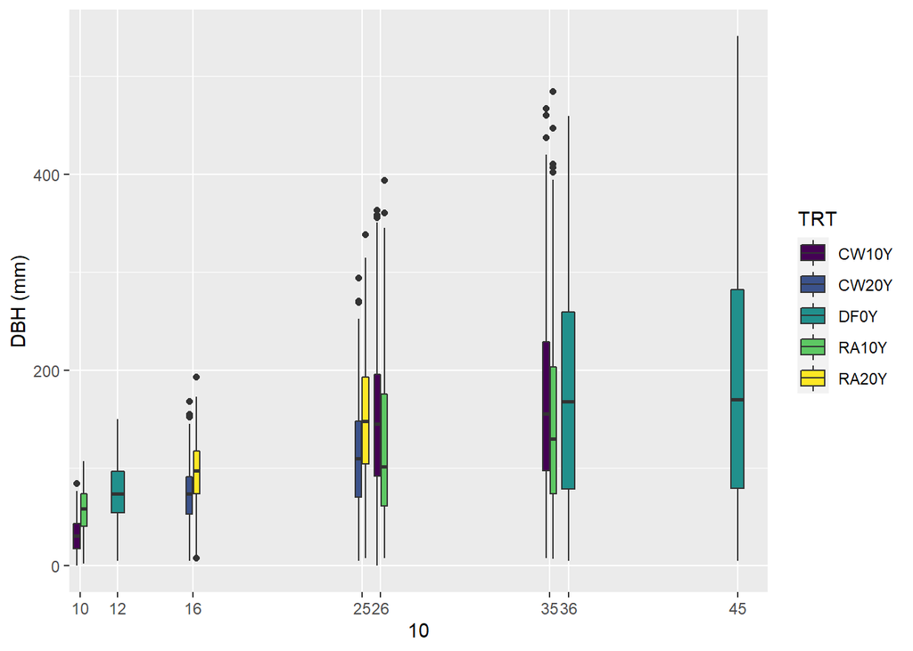

```r
#ggplot(long_data_keep,aes(x=DF_age,y=DBH_mm,color=TRT, alpha=0.2))+geom_jitter()+scale_color_viridis_d()+ylab("DBH (mm)")+xlab("Douglas Fir Age (years)")

#ggplot(long_data,aes(x=DF_age,y=DBH_mm,color=TRT, alpha=0.2))+geom_point(position="dodge2")+scale_color_viridis_d()+ylab("DBH (mm)")+xlab("Douglas Fir Age (years)")

#ggplot(long_data_keep,aes(x=DF_age,y=DBH_mm,fill=TRT))+geom_boxplot()+scale_fill_viridis_d()+ylab("DBH (mm)")+xlab("Douglas Fir Age (years)")

#ggplot(long_data_keep,aes(x=factor(DF_age),y=DBH_mm,fill=TRT))+geom_violin()+scale_fill_viridis_d()+ylab("DBH (mm)")+xlab("Douglas Fir Age (years)")+scale_x_discrete()

#plotting diameter as a function of DF_age across treatments
ggplot(long_data_keep,aes(x=factor(DF_age),y=DBH_mm,fill=TRT))+geom_boxplot()+scale_fill_viridis_d()+ylab("DBH (mm)")+xlab("Douglas Fir Age (years)")+scale_x_discrete(c("10","11","12","13","14","15","16","17","18","19","20","21","22","23","24","25","26","27","28","29","30","31","32","33","34","35","36","37","38","39","40","41","42","43","44","45","46"), drop=FALSE, limits= c("10","11","12","13","14","15","16","17","18","19","20","21","22","23","24","25","26","27","28","29","30","31","32","33","34","35","36","37","38","39","40","41","42","43","44","45","46"), breaks=c("10","12","16","25","26","35","36","45"))
```

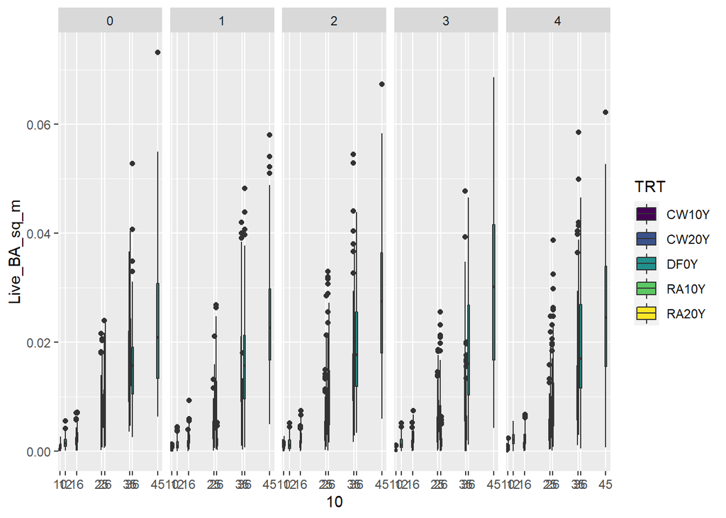

```r
#plotting live basal area as a function of DF_age across treatments
ggplot(long_data_keep,aes(x=factor(DF_age),y=Live_BA_sq_m,fill=TRT))+geom_boxplot()+scale_fill_viridis_d()+ylab("Live_BA_sq_m")+xlab("Douglas Fir Age (years)")+scale_x_discrete(c("10","11","12","13","14","15","16","17","18","19","20","21","22","23","24","25","26","27","28","29","30","31","32","33","34","35","36","37","38","39","40","41","42","43","44","45","46"), drop=FALSE, limits= c("10","11","12","13","14","15","16","17","18","19","20","21","22","23","24","25","26","27","28","29","30","31","32","33","34","35","36","37","38","39","40","41","42","43","44","45","46"), breaks=c("10","12","16","25","26","35","36","45")) +facet_grid(~REP,
             #scales = "free_x", # fix the x axis across facets.
             #space = "free_x",  # Let the width of facets vary and force all bars to have the same width.
             #switch = "x"
             )
```

```r
#create subplot and plot datasets and summary statistics including DF only for Shawn to test FVS with
#calculate summary statistics for live diameters
#calculate basal area with mm DBH
#calculate proportion surviving
#generate randomly sampled initial diameters
```

## Calculating live dbh and plotting status and live dbh distributions

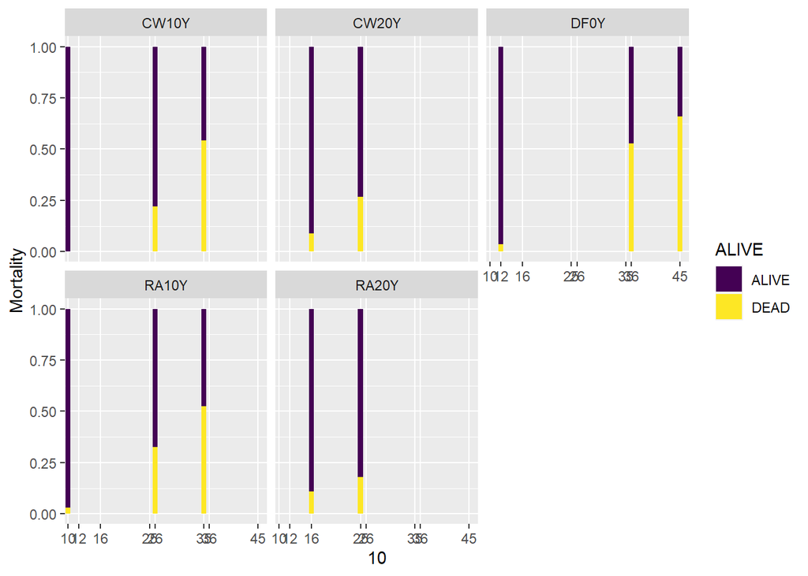

```r
#plotting viability as a function of DF_age across treatments
ggplot(data=subset(long_data_keep, !is.na(ALIVE)) ,aes(x=factor(DF_age),fill=ALIVE))+
  geom_bar(position="fill")+scale_fill_viridis_d()+
  ylab("Mortality")+
  xlab("Douglas Fir Age (years)")+
  scale_x_discrete(c("10","11","12","13","14","15","16","17","18","19","20","21","22","23","24","25","26","27","28","29","30","31","32","33","34","35","36","37","38","39","40","41","42","43","44","45","46"), drop=FALSE, limits= c("10","11","12","13","14","15","16","17","18","19","20","21","22","23","24","25","26","27","28","29","30","31","32","33","34","35","36","37","38","39","40","41","42","43","44","45","46"), breaks=c("10","12","16","25","26","35","36","45")) +
  facet_wrap(~TRT,
             #scales = "free_x", # fix the x axis across facets.
             #space = "free_x",  # Let the width of facets vary and force all bars to have the same width.
             #switch = "x"
             )
```

## Generating Plot and Stand level summaries

```r
#building from Woods Creek approach

#creating unique tree ID variable of format TRT_REP_SUBPLOT_TREE
long_data_keep$Tree_ID_TRS<-paste(long_data_keep$TRT_code,long_data_keep$REP,long_data_keep$SUBPLOT,long_data_keep$TREE, sep = "_")
#creating unique subplotplot ID factor varaible of format TRT_REP_SUBPLOT
long_data_keep$Subplot_ID_TRS<-as.factor(paste(long_data_keep$TRT_code,long_data_keep$REP,long_data_keep$SUBPLOT, sep = "_"))

#creating subplot level DF excluding trees with no status recorded (like 1987 measurements for ABDE and 1995 for CDE)
#sources for:
  #removing STATUS=NA https://stackoverflow.com/questions/29501188/dplyr-removing-nas-from-group-by-variable
  #excluding Live_BA_sq_m = 0 https://stackoverflow.com/questions/54805570/dplyr-summarise-keep-na-if-all-summarised-values-are-na/54805923
#subplot_df<-long_data_keep %>% filter(!is.na(STATUS)) %>% group_by(Subplot_ID_TRS, YEAR_fac,TRT, STATUS, .drop = TRUE) %>% summarise(count = n(), Live_BA_sq_m = if(all(is.na(Live_BA_sq_m))) NA_real_ else sum(Live_BA_sq_m, na.rm=TRUE))
#using DF age instead of year
subplot_df_age<-long_data_keep %>% filter(!is.na(STATUS)) %>% group_by(Subplot_ID_TRS, DF_age,TRT, STATUS, .drop = TRUE) %>% summarise(count = n(), Live_BA_sq_m = if(all(is.na(Live_BA_sq_m))) NA_real_ else sum(Live_BA_sq_m, na.rm=TRUE))
#adding the separate TMT, BLOCK, and PLOT columns
subplot_df_age<-subplot_df_age %>% separate(Subplot_ID_TRS, c("TRT","REP","SUBPLOT"),"_",remove = FALSE)
subplot_df_age$TRT<-as.factor(subplot_df_age$TRT)
subplot_df_age$REP<-as.factor(subplot_df_age$REP)
subplot_df_age$SUBPLOT<-as.factor(subplot_df_age$SUBPLOT)

#creating unique stand ID factor varaible of format TRT_BLOCK
subplot_df_age$Stand_ID_TR<-as.factor(paste(subplot_df_age$TRT,subplot_df_age$REP, sep = "_"))

stand_df_age<- subplot_df_age %>% filter(!is.na(STATUS)) %>% group_by(Stand_ID_TR, DF_age, TRT, STATUS, .drop = TRUE) %>% summarise(count = sum(count, na.rm=TRUE), Live_BA_sq_m = if(all(is.na(Live_BA_sq_m))) NA_real_ else sum(Live_BA_sq_m, na.rm=TRUE))
#adding the separate REP column
stand_df_age<-stand_df_age %>% separate(Stand_ID_TR, c(NA,"REP"),"_",remove = FALSE)
stand_df_age$REP<-as.factor(stand_df_age$REP)

#write_rds(subplot_df_age,"C:/Users/showa/Documents/GitHub/Apiary_LRR/subplot_df_age.Rds")
#write_rds(stand_df_age,"C:/Users/showa/Documents/GitHub/Apiary_LRR/stand_level_df_age.Rds")

#write_csv(subplot_df_age, "C:/Users/showa/Documents/GitHub/Apiary_LRR/subplot_df_age.csv")
#write_csv(stand_df_age, "C:/Users/showa/Documents/GitHub/Apiary_LRR/stand_df_age.csv")
```

COPIED FROM WOODS CREEK STATISTICAL ANALYSIS

```r
#stand_df <- readRDS("C:/Users/showa/Documents/GitHub/Apiary_LRR/stand_level_df.Rds")
#generate data subset for ANOVA
AOV_in<-stand_df_age

AOV_alive<-subset(AOV_in, AOV_in$STATUS==1)
AOV_alive_count<- AOV_alive %>% group_by(Stand_ID_TR, DF_age)%>%summarise(alive=sum(count, na.rm=TRUE), Live_BA_sq_m = if(all(is.na(Live_BA_sq_m))) NA_real_ else sum(Live_BA_sq_m, na.rm=TRUE))
AOV_dead<-subset(AOV_in, AOV_in$STATUS==3)
AOV_dead_count<- AOV_dead %>% group_by(Stand_ID_TR, DF_age)%>%summarise(dead=sum(count, na.rm=TRUE), Live_BA_sq_m = if(all(is.na(Live_BA_sq_m))) NA_real_ else sum(Live_BA_sq_m, na.rm=TRUE))
#attempt to merge datasets but there are not "dead" entries for all of the stand/year combinations
#need to add rows for stand years with zero dead trees https://www.statology.org/r-append-to-data-frame/
dead_add<-data.frame("Stand_ID_TR"=c("A_4", "B_2", "B_3", "B_4"),
                     "DF_age"=c(10, 10, 10, 10),
                     "dead"=c(0, 0, 0, 0),
                     "Live_BA_sq_m"=c(NA, NA,NA, NA))

dead_add$Stand_ID_TR<-as.factor(dead_add$Stand_ID_TR)
dead_add$DF_age<-as.double(dead_add$DF_age)
dead_add$dead<-as.integer(dead_add$dead)
dead_add$Live_BA_sq_m<-as.double(dead_add$Live_BA_sq_m)
AOV_dead_count_add<-rbind(AOV_dead_count, dead_add)
#need to have rows in same order to cbind
AOV_dead_count_add<-AOV_dead_count_add[c(1:10,60,11:18,61,19:20,62,21,22,63,23:59),]
AOV_prop_dead<-cbind(AOV_alive_count, AOV_dead_count_add["dead"])
AOV_prop_dead$total<-(AOV_prop_dead$alive+AOV_prop_dead$dead)
AOV_prop_dead$prop_dead<-(AOV_prop_dead$dead/AOV_prop_dead$total)


#add unique block and tmt designations and make them factors
AOV_prop_dead<-AOV_prop_dead %>% separate(Stand_ID_TR, c("TRT","REP"),"_",remove = FALSE)
AOV_prop_dead$TRT<-as.factor(AOV_prop_dead$TRT)
AOV_prop_dead$REP<-as.factor(AOV_prop_dead$REP)
#arcsine transforrmation of proportion dead
AOV_prop_dead$asn<-asin(sqrt(AOV_prop_dead$prop_dead))
#adding descriptive treatment name
AOV_prop_dead$Tname<-ifelse(AOV_prop_dead$TRT=="A",
                            "RA10",
                            ifelse(AOV_prop_dead$TRT=="B",
                               "CW10",
                               ifelse(AOV_prop_dead$TRT=="C",
                                      "DF0",
                                      ifelse(AOV_prop_dead$TRT=="D",
                                             "RA20",
                                             "CW20"))))
```

## Plotting

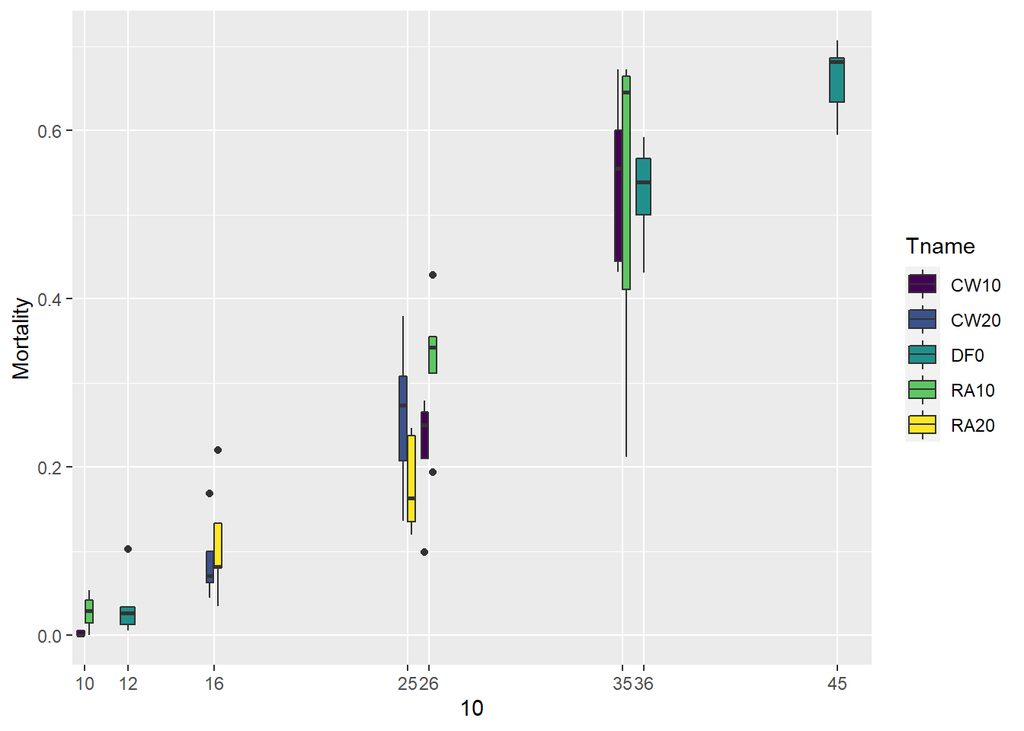

```r
#ANOVA FINALLY????????
#example provided by stats consult https://rpubs.com/tmcurley/twowayanova
#len.aov <- aov(len ~ supp + dose + supp:dose, data = ToothGrowth)
#summary(len.aov)
#Proportion dead

#somehow modify to run the anova on years independently, or add year as a covariate?
#plot asn prop mort x DF age, fit slopes by TRT?


ggplot(AOV_prop_dead,aes(x=factor(DF_age),y=prop_dead, fill=Tname)) + geom_boxplot()+
   ylab("Mortality")+
  xlab("Douglas Fir Age (years)")+
  scale_x_discrete(c("10","11","12","13","14","15","16","17","18","19","20","21","22","23","24","25","26","27","28","29","30","31","32","33","34","35","36","37","38","39","40","41","42","43","44","45","46"), drop=FALSE, limits= c("10","11","12","13","14","15","16","17","18","19","20","21","22","23","24","25","26","27","28","29","30","31","32","33","34","35","36","37","38","39","40","41","42","43","44","45","46"), breaks=c("10","12","16","25","26","35","36","45")) +scale_fill_viridis_d()
```

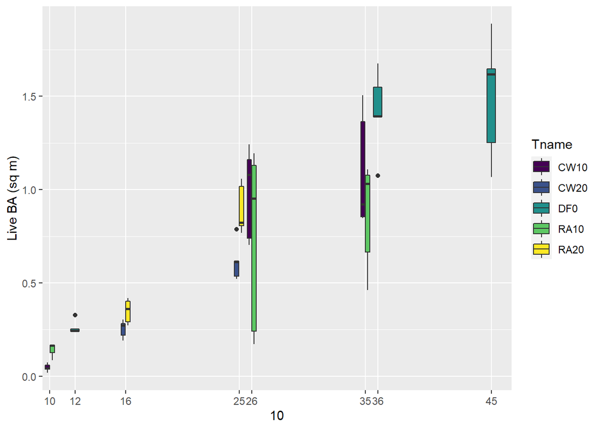

```r
ggplot(AOV_prop_dead,aes(x=factor(DF_age),y=Live_BA_sq_m, fill=Tname)) + geom_boxplot()+
   ylab("Live BA (sq m)")+
  xlab("Douglas Fir Age (years)")+
  scale_x_discrete(c("10","11","12","13","14","15","16","17","18","19","20","21","22","23","24","25","26","27","28","29","30","31","32","33","34","35","36","37","38","39","40","41","42","43","44","45","46"), drop=FALSE, limits= c("10","11","12","13","14","15","16","17","18","19","20","21","22","23","24","25","26","27","28","29","30","31","32","33","34","35","36","37","38","39","40","41","42","43","44","45","46"), breaks=c("10","12","16","25","26","35","36","45")) +scale_fill_viridis_d()
```